# Intro

All of the violin plots were plotted using matplotlib. To learn more about matplotlib, visit https://matplotlib.org/. To learn more about violin plots specifically, https://stackabuse.com/matplotlib-violin-plot-tutorial-and-examples/ is a good tutorial that shows how to effectively use a violin plot to represent data.

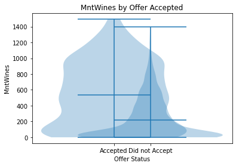

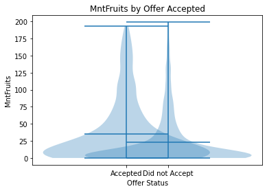

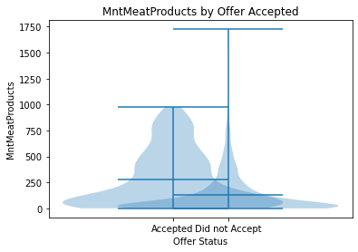

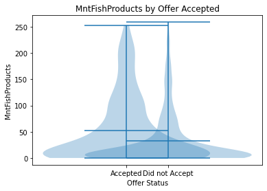

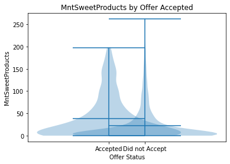

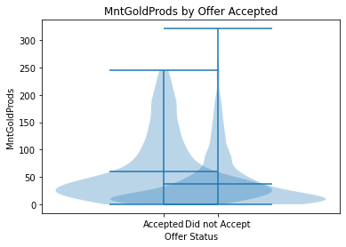

```python
#Creating a plot of purchases by whether or not customer accepted any offer
mnt = ["MntWines", "MntFruits", "MntMeatProducts", "MntFishProducts", "MntSweetProducts", "MntGoldProds"]
nums = [0, 1]

#Looping over all categories
for category in mnt:

    #Array to hold purchase data for a specific category
    x_amount = []

    #Getting values for those that accepted an offer
    purchases = cust_data.loc[cust_data["AcceptedAny"] == True, category]
    x_amount.append(purchases)

    #Getting values for those that did not accept any offer
    purchases = cust_data.loc[cust_data["AcceptedAny"] == False, category]
    x_amount.append(purchases)

    #Creating plot
    fig, ax = plt.subplots()

    ax.violinplot(x_amount, nums,widths=4,showmeans=True)
    ax.set_xticks(nums)
    ax.set_xticklabels(["Accepted", "Did not Accept"])

    ax.set_xlabel("Offer Status")
    ax.set_ylabel(category)
    ax.set_title(f"{category} by Offer Accepted")
```

Now we will plot two more graphs, one for the amount of kids in a household, and one for the amount of teens in a household. This is a very similar process to the last set of graphs.

As one can see, the violins for kids and teens do not differ significantly between each other or "AcceptedAny." This means that the amount of kids and teens in a household likely have little to no effect on whether or not a customer accepts a promotional offer.

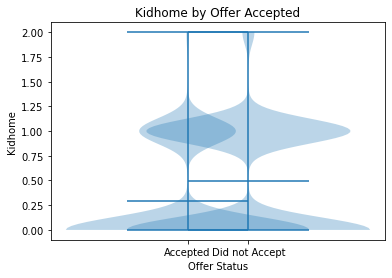

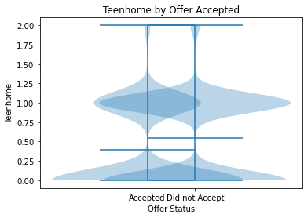

```python
#Creating a plot of kids and teens by whether or not customer accepted any offer
home_status = ["Kidhome", "Teenhome"]
nums = [0, 1]

#Looping over all categories
for category in home_status:

    #Array to hold dependents data for a specific category
    x_amount = []

    #Getting values for those that accepted an offer
    purchases = cust_data.loc[cust_data["AcceptedAny"] == True, category]
    x_amount.append(purchases)

    #Getting values for those that did not accept any offer
    purchases = cust_data.loc[cust_data["AcceptedAny"] == False, category]
    x_amount.append(purchases)

    #Creating plot
    fig, ax = plt.subplots()

    ax.violinplot(x_amount, nums,widths=4,showmeans=True)
    ax.set_xticks(nums)
    ax.set_xticklabels(["Accepted", "Did not Accept"])

    ax.set_xlabel("Offer Status")
    ax.set_ylabel(category)
    ax.set_title(f"{category} by Offer Accepted")
```

We will repeat the process again, except this time we will only have one violin plot for "Income" vs "AcceptedAny." We will drop the outlier customer with an income of $666,666 because there is no one remotely close to them in come and they skew the scale of the data to the point of making the plot difficult to read. Other than that, this plot is business as usual.

Income does seem to vary depending on whether or not someone accepted a promotional offer, so we will keep it in mind moving forward.

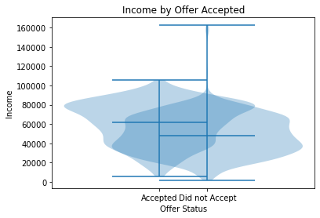

```python
#Creating a plot of income by whether or not customer accepted any offer
#Dropping income outlier since it made data unreadable
adjusted_data = cust_data.drop(cust_data[cust_data["Income"] == 666666].index)

#Array to hold income data for a specific category
x_amount = []

#Getting values for those that accepted an offer
purchases = adjusted_data.loc[adjusted_data["AcceptedAny"] == True, "Income"]
x_amount.append(purchases)

#Getting values for those that did not accept any offer
purchases = adjusted_data.loc[adjusted_data["AcceptedAny"] == False, "Income"]
x_amount.append(purchases)

#Creating plot
fig, ax = plt.subplots()

ax.violinplot(x_amount, nums,widths=4,showmeans=True)
ax.set_xticks(nums)
ax.set_xticklabels(["Accepted", "Did not Accept"])

ax.set_xlabel("Offer Status")
ax.set_ylabel("Income")
ax.set_title("Income by Offer Accepted")
```

As one can see from the plot, there is a considerable difference in the two violins, leading me to believe that Total_Spent is an important metric for predicting if a customer accepted an offer.

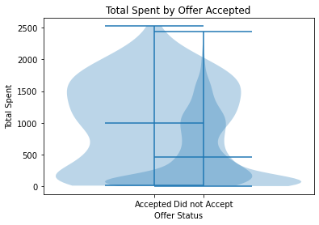

```python
#Creating a plot of income by whether or not customer accepted any offer

#Array to hold income data for a specific category
x_amount = []

#Getting values for those that accepted an offer
purchases = Purchase_dataset.loc[Purchase_dataset["AcceptedAny"] == True, "Total_Spent"]
x_amount.append(purchases)

#Getting values for those that did not accept any offer
purchases = Purchase_dataset.loc[Purchase_dataset["AcceptedAny"] == False, "Total_Spent"]
x_amount.append(purchases)

#Creating plot
fig, ax = plt.subplots()

ax.violinplot(x_amount, nums,widths=4,showmeans=True)
ax.set_xticks(nums)
ax.set_xticklabels(["Accepted", "Did not Accept"])

ax.set_xlabel("Offer Status")
ax.set_ylabel("Total Spent")
ax.set_title("Total Spent by Offer Accepted")
```

# Analysis

Given all of the variables that we analyzed, it seems that "Total_Spent" is the best predictor for whether or not someone accepted a promotional offer. Since MntWines and the other individual purchases are used to calculate Total_Spent, it would be redundant to include them. Meanwhile, the amount of teens and kids in a household seem to have very little to do with the target variable. Finally, "Income" and "Total_Spent" are correlated, and we want to avoid colinearity when performing our hypothesis test, so we will use "Total_Spent" since it is the superior of the two.

Our hypothesis is thus "There is a relationship between the total spent on goods and whether or not a customer accepted a promotional offer," while the null hypothesis is that "There is no relationship between total spent on goods and whether a customer accepted a promotional offer." Since "Total_Spent" is a continuous variable, and "AcceptedAny" is a binary one, we will be using logistical regression.

To learn more about sklearn, visit https://scikit-learn.org/stable/. To learn about how to use logistic regression, visit https://scikit-learn.org/stable/modules/generated/sklearn.linear_model.LogisticRegression.html. Finally, to learn more about hypothesis tests and why I chose logistical regression, visit https://www.scribbr.com/statistics/statistical-tests/.

# Hypothesis

We will split up our data into training and test sets using the train_test_split from sklearn to split our data, with 70% of the data being used to train the model, and the remaining 30% being used to test it. We can then create the model by fitting the X_train and y_train data to a logistic regression object from sklearn. Finally, we can run a quick test using score() to determine the accuracy of the model on the test set.

```python
#Preparing data to be processed
X = np.array(Purchase_dataset["Total_Spent"]).reshape(-1, 1)
#X = Purchase_dataset[["Income", "Total_Spent"]]
Y = cust_data["AcceptedAny"]

#Splitting into training and test sets
X_train, X_test, y_train, y_test = train_test_split(
    X, Y, test_size = .3, random_state = 0)
```

```python
#Creating the model
logr = LogisticRegression()
logr.fit(X_train, y_train)
score = logr.score(X_test, y_test)
print(score)
```

```
0.7654135338345864
```

We can also use a confusion matrix (courtesy once again of sklearn) to get a better representation of how our model performed. Since our target variable is binary, the confusion matrix is a 2x2 matrix that shows the amount of true positives, false positives, false negatives, and true positives of our model on the test set. The non-normalized matrix simply shows how many results fall into each category, while the normalized matrix shows the percentage of each one.

Unfortunately, tuning hyperparameters did not do much to improve the model. LogisticRegression() has a lot of hyperparameters, but tuning all of them led to the same or even poorer results. Leaving the model in it's default state seems to yield the best results.

A great tutorial on implementing sklearn confusion matrices can be found at https://www.jcchouinard.com/confusion-matrix-in-scikit-learn/.

```
Confusion matrix, without normalization
Normalized confusion matrix
```

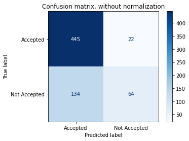

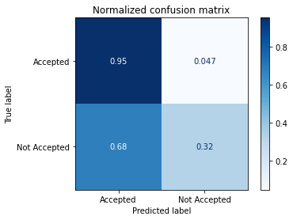

```python
# Plotting a confusion matrix
titles_options = [
    ("Confusion matrix, without normalization", None),
    ("Normalized confusion matrix", "true"),
]

for title, normalize in titles_options:
    disp = ConfusionMatrixDisplay.from_estimator(
        logr,
        X_test,
        y_test,
        display_labels=["Accepted", "Not Accepted"],
        cmap=plt.cm.Blues,
        normalize=normalize,
    )

    disp.ax_.set_title(title)

    print(title)

plt.show()
```

# Conclusion

Overall, while we did not achieve the results we were hoping for, we still gained a lot of insight into how different customer variables interact with each other. Ultimately, it is pretty much impossible to perfectly segment a customer base. Regardless of how they are represented here, people are still individuals and there will always be some customers who cannot be perfectly clustered and therefore cannot be perfectly advertised to.